# Exam 1

## Exam 1

#### Metainformation

1. | Tag | Value |
   | --- | --- |
   | `file` | Inferential_Statistics_vufsw-t-test-1326-nl_vufsw-t-test-1326-nl |
   | `name` | vufsw-t-test-1326-nl |
   | `section` | inferential statistics/parametric techniques/t-test |
   | `type` | schoice |
   | `solution` | TRUE, FALSE, FALSE, FALSE |
   | `Type` | interpreting output |
   | `Program` | NA |
   | `Language` | dutch |
   | `Level` | statistical thinking |

#### Question

   In een experiment over het effect van voedselmarketing op koopintenties (Laura Sjardin, Josephine Ruijs, Nora Michon en Lianne van der Poel, 2017) kregen 182 respondenten via een online survey een foto op Instagram van een gezonde ‘juice’ (vruchtensap) te zien. De respondenten werden willekeurig in twee groepen ingedeeld: de helft kreeg een foto te zien van de juice die 28 likes had; de andere helft een foto van een juice die 106.613 likes had. Daarna moesten de respondenten aangeven in hoeverre ze van plan zouden zijn om de juice te kopen (‘buyinginterest’: een hogere score betekent een hogere koopintentie). De vraag was of het tonen van een juice met veel likes tot een hogere koopintentie leidt dan een juice met weinig likes.

   28 ‘likes’: 106.613 ‘likes’:

[figure not shown]

[figure not shown]

   Hieronder staan de resultaten van een independent t-test.

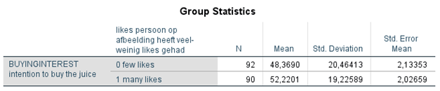

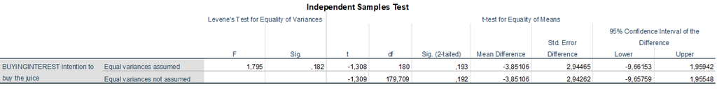

   Uit de resultaten van de analyse kunnen we opmaken dat…
   1. **TRUE:** De intentie om de juice te kopen groter is wanneer de juice veel ‘likes’ heeft dan wanneer de juice weinig ‘likes’ heeft; het verschil is niet significant
   2. **FALSE:** De intentie om de juice te kopen groter is wanneer de juice veel ‘likes’ heeft dan wanneer de juice weinig ‘likes’ heeft; het verschil is significant
   3. **FALSE:** De intentie om de juice te kopen minder groot is wanneer de juice veel ‘likes’ heeft dan wanneer de juice weinig ‘likes’ heeft; het verschil is niet significant
   4. **FALSE:** De intentie om de juice te kopen minder groot is wanneer de juice veel ‘likes’ heeft dan wanneer de juice weinig ‘likes’ heeft; het verschil is significant
   1. True
   2. False
   3. False
   4. False